# Analyzing time series data using the ‘permutes’ package

Cesko Voeten

8 December 2017

This vignette models EEG data, an example of *time series data*, using generalized additive mixed modeling (Wood, 2006) and permutation testing (Maris & Oostenveld, 2007). Since both techniques rely fundamentally on the linear model of regression, we will first *very* briefly introduce the relevant mathematical foundations. The reader familiar with basic statistics can safely skip this section.

The linear model is summarized by the following equation:

$$Y = X\beta + \epsilon, \quad \epsilon \sim \mathcal{N}(0,\sigma^{2}I)$$

where $Y$ is a transposed vector (or a matrix, in the case of a multivariate response) known as the *outcome* (or alternatively, the *response*), $X$ is the *design matrix*, $\beta$ is a vector of *regression coefficients*, and $\epsilon$ is the unknown error, which is assumed to be normally distributed (in other words, i.i.d. Gaussian). Leaving out the unpredictable error gives us the modified regression equation below, which *estimates* the outcome by multiplying the predictors with estimated regression coefficients:

$$\hat{Y} = X\hat{\beta}$$

By construction, the residuals of this model sum to zero, but squaring them provides the *sum of squared residuals*:

$$r^2 = (\hat{Y} - X\hat{\beta})^2$$

The objective of linear regression is to find the estimates for $\hat{\beta}$ that minimize $r^2$ – in other words, to find the model that explains the most of the total variance. This is not difficult, because from defining the objective function as a squared quantity and assuming normal errors, it follows that the range of $r^2$ is *convex*, i.e. that there is no maximum and a single minimum. Finding the values for $\hat{\beta}$ that minimize the residuals is then simply a matter of differentiating $r^2$ with respect to $\hat{\beta}$ and solving for 0:

$$\begin{aligned}
r^2 &= (\hat{Y} - X\hat{\beta})^2 \\
&= (\hat{Y} - X\hat{\beta})^{\mathsf{T}}(\hat{Y} - X\hat{\beta}) \\
&= (\hat{Y}^{\mathsf{T}} - X^{\mathsf{T}}\hat{\beta}^{\mathsf{T}})(\hat{Y} - X\hat{\beta}) \\
&= \hat{Y}^{\mathsf{T}}\hat{Y} - \hat{Y}^{\mathsf{T}}X\hat{\beta} - X^{\mathsf{T}}\hat{\beta}^{\mathsf{T}}\hat{Y} + X^{\mathsf{T}}X\hat{\beta}^2 \\
\frac{\partial r^2}{\partial\mathcal{\hat{\beta}}} &= 0 - \hat{Y}^{\mathsf{T}}X - X^{\mathsf{T}}\hat{Y} + 2X^{\mathsf{T}}X\hat{\beta} \\
0 &= 0 - 2X^{\mathsf{T}}\hat{Y} + 2X^{\mathsf{T}}X\hat{\beta} \\
-2X^{\mathsf{T}}X\hat{\beta} &= -2X^{\mathsf{T}}\hat{Y} \\
\hat{\beta} &= (X^{\mathsf{T}}X)^{-1}X^{\mathsf{T}}\hat{Y}
\end{aligned}$$

The covariance matrix is given by:

$$\hat{\sigma}(X^{\mathsf{T}}X)^{-1}, \quad \hat{\sigma} = \sqrt{\sigma^2}, \quad \sigma^2 = \frac{r^2}{\mathit{df}}$$

The degrees of freedom for calculating the mean squared error are defined as $\mathit{df} = n - p$, where $n$ is the number of observations and $p$ is the number of predictors in the model. Subtracting $p$ from $n$ compensates for inaccuracy in the estimation of $\beta$ by $\hat{\beta}$, which will have inflated the residuals $(Y - X\hat{\beta})^2$ away from their true values $(Y - X\beta)^2$ (remember that the residuals are squared, so this bias accumulates rather than canceling out). Accounting for this bias by artificially inflating the denominator results in $s$ being an unbiased estimator of the ‘true’ mean squared error. Having the covariance matrix makes it possible to derive $t$-values by dividing the $\hat{\beta}$ by their standard errors, which are the square roots of the diagonal of the covariance matrix:

$$t_i = \frac{\hat{\beta}_i}{\sqrt{\mathit{Cov}_{i,i}}}$$

Analysis of variance squares these values and reports them as $F$ instead, in the standard case of Type III (‘marginal’) SS. (For the ‘sequential’ types of SS, ANOVA works by performing the appropriate model comparison, in which case the difference in $r^2$ between the models is compared to the $F$ distribution with the appropriate degrees of freedom.)

The model so far only contains *fixed effects*. The extension with *random effects* is:

$$Y = X\beta + Zb + \epsilon, \quad \epsilon \sim \mathcal{N}(0,\sigma^{2}I)$$

where $Z$ is the design matrix for the random effects and $b$ is again an unknown vector of regression coefficients. The values of these coefficients are estimated using (restricted) maximum likelihood, which is computationally intractable if we don’t assume some additional structure, namely:

$$Y = X\beta + Z\Lambda_\theta u + \epsilon, \quad u \sim \mathcal{N}(0,\sigma_1^{2}I), \quad \epsilon \sim \mathcal{N}(0,\sigma_2^{2}I)$$

where $u$ and $\epsilon$ (and $\sigma_1^{2}I$ and $\sigma_2^{2}I$) are independent of each other. In this formulation $b$ is decomposed into $\Lambda_\theta u$. $\Lambda_\theta$ is the relative covariance matrix for the random effects; it denotes those parts of the (co)variances that should be attributed to the random effects as opposed to the fixed effects or $\epsilon$, relative to the overall model $\hat{\sigma}$. This matrix is block-diagonal, and is hence sparse; the non-zero entries are filled with $\theta$-values, which have to be estimated. Which of the entries are non-zero depends on the parametrization; if we allow all entries to vary freely, the model will have to estimate $n\times(n+1)/2$ parameters (because $\mathit{Cov}_{x,y} \equiv \mathit{Cov}_{y,x}$) per random effect. `mgcv`, the package for generalized additive modeling that we will use, assumes that the off-diagonal entries (the correlations) are zero, and that each block in $\Lambda_\theta$ can be represented as a multiple of the identity matrix, therefore reducing the number of parameters to be estimated to one per random effect.

Note that only the $\theta$ parameters in $\Lambda_\theta$ have to be estimated via (restricted) maximum likelihood. Maximum likelihood is the iterative process of finding numerically the values for, in our case, $\theta$, that maximize the likelihood of the data. For computational reasons, the packages available for calculating mixed-effects models do not maximize the likelihood $\ell$, but rather minimize the deviance, which is just $-2 \mathit{log}(\ell)$. It is apparently (Bates & DebRoy, 2004) not difficult to integrate out the unknown $u$ during this optimization process. After convergence, this will yield the best linear unbiased estimators for $\beta$ and $\theta$ from which it is only then necessary to calculate coefficients for $u$.

This is about as much detail as is needed to understand the `mgcv` analysis provided at the end, with one important addition. Because the values for $\theta$ and hence $u$ are estimated so as to maximize the likelihood of the data, it is customary to add the squared sum of the estimates $\tilde{u}$ as a penalty term so that extreme values estimated for $u$ artificially inflate the deviance. This promotes shrinkage of these coefficients towards zero, and is the backbone of `mgcv`’s approach to smooth estimation. This will be further detailed in the paragraph dedicated to the GAMM analysis.

## Why time series data are special

The dataset we will be working with is called `MMN`, which is an excerpt from a passive-oddball task conducted by Jager (in prep.). A proper method section with more details should eventually be found in that paper, but a brief and incomplete summary follows here in order to make it easier to work with the data. Jager (in prep.) presented Dutch learners of English with a stream of isolated vowels from English or from Dutch created by means of formant synthesis. Each of her six conditions (summarized in the below table; the package supplies data from two of these conditions) each having used four vowels: three of the same phonetic category (e.g. three realizations of the DRESS vowel with slightly different formant frequencies) and one of a different phonetic category (e.g. the TRAP vowel). The first set of vowels, termed ‘standards’, were presented frequently; the fourth vowel, the ‘deviant’, infrequently interrupted the stream of standards. Participants were instructed not to pay attention to this stream of sounds, and watched a silent movie to keep them occupied. EEG recordings of 30 electrodes (T7 and T8 were excluded) were recorded while the participants were exposed to the vowel stimuli. At the presentation of one of the deviant vowels, we expect to observe a negative deflection in the EEG signal about 200 milliseconds after stimulus onset, originating from frontal and central electrode sites. This effect is called the ‘mismatch negativity’. A second effect called the ‘P300’ may also occur, but is ignored here. The vowel pairs tested in Jager (in prep.) are summarized in the below table; the data supplied with `permutes` are a subset consisting of S13 vs. S94 (DRESS as a standard vs. as a deviant) and S16 vs. S95 (ZAT as a standard vs. as a deviant).

| Code | Corresponding standard | Corresponding deviant |
| --- | --- | --- |
| S11 or S91 | ZET | DRESS |
| S12 or S92 | DRESS | ZET |
| S13 or S93 | DRESS | TRAP |
| S14 or S94 | TRAP | DRESS |
| S15 or S95 | ZET | ZAT |
| S16 or S96 | ZAT | ZET |

The first few rows of the data look as follows:

```r
library(permutes)
head(MMN)
```

```
##         Fp1     AF3      F7      F3    FC1     FC5      C3     CP1     CP5
## 769 -1.8819  0.2637 -0.6339 -0.5369 0.3605  0.6546 -0.1360 -0.3824 -0.2467
## 770 -1.5811  0.2429 -0.5817 -0.5476 0.3723  0.4233 -0.2799 -0.3673 -0.3039
## 771 -1.2132  0.1748 -0.5282 -0.5543 0.3645  0.2103 -0.4002 -0.3030 -0.3402
## 772 -0.8486  0.0609 -0.4839 -0.5335 0.3388  0.0170 -0.4797 -0.2047 -0.3537
## 773 -0.5375 -0.0973 -0.4516 -0.4804 0.2994 -0.1490 -0.5150 -0.0923 -0.3529
## 774 -0.2892 -0.2683 -0.4246 -0.4078 0.2580 -0.2589 -0.5064  0.0189 -0.3474
##          P7      P3      Pz     PO3      O1      Oz      O2     PO4
## 769 -0.3253 -0.6873 -0.8139 -0.6393 -0.9595 -1.4620 -1.2554 -1.6028
## 770 -0.3180 -0.5955 -0.8088 -0.6527 -0.9664 -1.4524 -1.1569 -1.4998
## 771 -0.2925 -0.4985 -0.7544 -0.6393 -0.9325 -1.4179 -1.0198 -1.3673
## 772 -0.2459 -0.4092 -0.6773 -0.6126 -0.8756 -1.3698 -0.8718 -1.2345
## 773 -0.1823 -0.3422 -0.6095 -0.5931 -0.8252 -1.3267 -0.7427 -1.1249
## 774 -0.1128 -0.3093 -0.5731 -0.6006 -0.8122 -1.3060 -0.6530 -1.0477
##          P4      P8     CP6     CP2     C4    FC6    FC2     F4     F8
## 769 -0.9905 -0.3362 -0.0847 -0.6391 0.4028 2.3192 0.6892 1.4870 0.6433
## 770 -0.8125 -0.1618  0.1654 -0.4452 0.6595 2.6499 0.8777 1.3410 0.6399
## 771 -0.6238  0.0271  0.3529 -0.2325 0.8683 2.7869 1.0239 1.1184 0.6470
## 772 -0.4587  0.1942  0.4282 -0.0461 0.9820 2.7140 1.0996 0.8637 0.6663
## 773 -0.3384  0.3129  0.3924  0.0821 0.9904 2.4648 1.0976 0.6197 0.6986
## 774 -0.2608  0.3788  0.3083  0.1503 0.9329 2.1185 1.0392 0.4281 0.7312
##         AF4     Fp2     Fz     Cz      time ppn session cond  dev
## 769 -0.4083 -1.0715 0.7902 0.4035  1.171875   1   FALSE  S13 TRUE
## 770 -0.2220 -0.5532 0.8840 0.4983  3.125000   1   FALSE  S13 TRUE
## 771 -0.0992  0.1172 0.9133 0.5953  5.078125   1   FALSE  S13 TRUE
## 772 -0.0532  0.8056 0.8751 0.6761  7.031250   1   FALSE  S13 TRUE
## 773 -0.0520  1.3555 0.7887 0.7273  8.984375   1   FALSE  S13 TRUE
## 774 -0.0574  1.6360 0.6891 0.7515 10.937500   1   FALSE  S13 TRUE
```

```r
nrow(MMN) #how many observations?
```

```
## [1] 44814
```

```r
length(unique(MMN$time)) #how many timepoints?
```

```
## [1] 231
```

The first 30 columns are the 30 sampled EEG electrodes. The `time` column denotes the moment from stimulus onset, in milliseconds, of each measurement type. `ppn` is the participant, and `session` is the session of the experiment minus one, to make it a proper dummy indicating whether the datapoint is from the first (0) or the second session (1). `cond` indicates the condition code, which can be decoded from the table. Finally, `dev` is a dummy indicating whether the stimulus was a standard (0) or a deviant (1), explained in the next paragraph. Note that, contrary to the results and recommendations in Brysbaert (2007), Jager (in prep.) averaged over all her items belonging to the same condition in this experiment.

Time series data such as these are special because the data consist of multiple, *strongly correlated*, measurements of the same signal. This generates two problems. The first is a research problem: which portion of this time series do we want to analyze? The `permutes` package was designed to help researchers answer precisely this question. The second problem is of a statistical nature: how do we handle the strong autocorrelation present throughout this sampled window? Note that in the case of EEG data, these same two problems are additionally encountered in the *spatial* domain: what combination of electrodes (‘region of interest’) do we want to analyze, and how do we deal with the spatial correlation present in data measured from neighboring sites? This issue is dealt with in the `permutes` package by running separate analyses for each site, as is shown below.

## Determining the window and ROI

The first problem equates to what is known in the EEG literature as determining the *window*. The normal way to do this is to run a MANOVA (with the 30 electrodes as the dependent variables) on every individual timepoint, and take as the window the point where a large sequence of significant $p$-values occurs. If we plot time horizontally and the electrode site vertically, we can use this approach to select both a time window and an ROI at the same time.

The below code runs a permutation test series on the `MMN` data and plots the results as a heatmap. Note that permutation testing is not deterministic (the permutations are chosen randomly), so your results may be slightly different from mine.

```r
perms <- permu.test(cbind(Fp1,AF3,F7,F3,FC1,FC5,C3,CP1,CP5,P7,P3,Pz,PO3,O1,Oz,O2,PO4,
    P4,P8,CP6,CP2,C4,FC6,FC2,F4,F8,AF4,Fp2,Fz,Cz) ~ dev | time,data=MMN)
## (output not shown)
```

This takes a few seconds to run. We can speed it up by parallelizing the testing of the individual timepoints:

```r
library(doParallel)
cl <- makeCluster(2) #or more
registerDoParallel(cl)
perms <- permu.test(cbind(Fp1,AF3,F7,F3,FC1,FC5,C3,CP1,CP5,P7,P3,Pz,PO3,O1,Oz,O2,PO4,
    P4,P8,CP6,CP2,C4,FC6,FC2,F4,F8,AF4,Fp2,Fz,Cz) ~ dev | time,data=MMN,parallel=TRUE)
```

We can then plot the results:

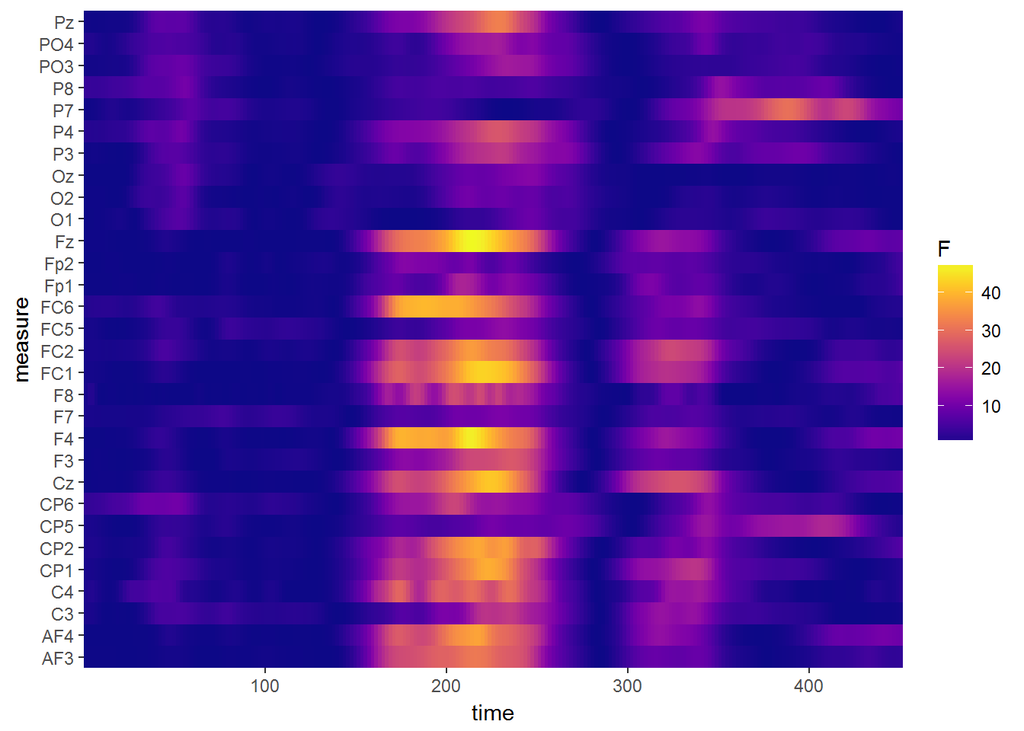

```r
plot(perms)
```

Following Maris & Oostenveld (2007), the `plot` method from `permutes` by default plots $F$-values. Maris & Oostenveld (2007) then compute a cluster statistic over a range of temporally and/or spatially adjacent $F$-values that all match an inclusion criterion (e.g. $p<.05$). This cluster statistic is not explicitly calculated by `permutes` (in the general case, `permutes` does not know which responses in any multivariate design should be considered adjacent), but the clusters can be identified by the researcher based on visual inspection, and the researcher can then run any test they want on the subset of data falling within the cluster. If the we want to stick to Maris & Oostenveld (2007), this test should be another permutation ANOVA over the whole window, but we will see below that generalized additive models offer a much better option than ANOVA, by virtue of being able to take into account the temporal and spatial correlations present in the data.

Based on visual inspection, the plot suggests two windows: one window located around 200 ms post-stimulus-onset, and a second window located around 330 ms post-stimulus-onset. The first window corresponds to the expected mismatch-negativity effect; the second window is likely a P300, which we will ignore here. The region of interest can be tentatively estimated as frontal and central (which is good news for Jager (in prep.), as this is in line with prior literature on the MMN component), but we would like some formal verification. One option is to follow Maris & Oostenveld (2007) in discarding those results that have failed to achieve significance; we can then check again for contiguous bands that achieve large effect sizes, and base our ROI on their positions. Because `permutes` objects are also normal data frames, it is straightforward to gray out non-significant effects:

```r
head(perms) #take a look at the data structure
```

```
##   measure     time factor          F         p w2
## 1     Fp1 1.171875   dev1 0.09178628 1.0000000  0
## 2     AF3 1.171875   dev1 0.05385531 1.0000000  0
## 3      F7 1.171875   dev1 0.71211641 0.3194444  0
## 4      F3 1.171875   dev1 0.03319517 1.0000000  0
## 5     FC1 1.171875   dev1 0.46076980 0.6333333  0
## 6     FC5 1.171875   dev1 0.52581697 0.7647059  0
```

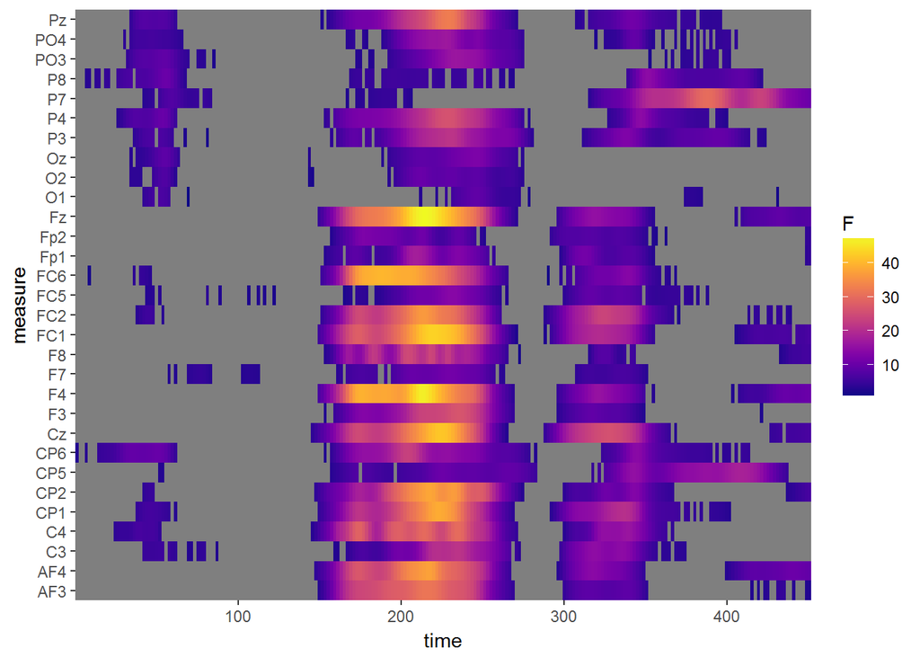

```r
perms[perms$p >= .05,c('F','w2')] <- NA
plot(perms)
```

From this plot, the effects look to be relatively robust at, indeed, the frontal and central regions. As a next step, we should determine the temporal window with more precision. To do so, we will compute cluster statistics by summing the $F$-values belonging to the relevant electrodes, and plot them as a function of the time. We can then define arbitrary cutoff points for including/excluding a part of the larger time window.

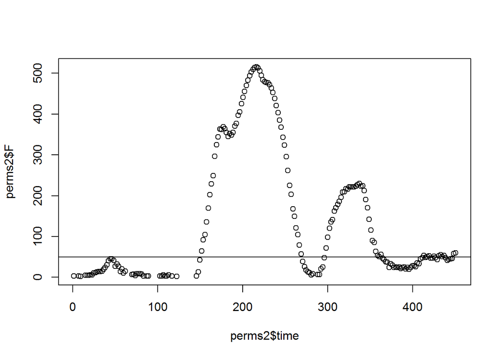

```r
perms2 <- perms[perms$measure %in% .(Fp1,AF3,F7,F3,FC1,FC5,C3,CP1,CP5,CP6,CP2,C4,FC6,FC2,
    F4,F8,AF4,Fp2,Fz),]
perms2$measure <- 'Aggregate'
perms2 <- aggregate(. ~ measure + time + factor,perms2,sum)
plot(perms2$time,perms2$F)
abline(h=50)
```

Based on the plot, a cut-off $F$ value of 50 seems reasonable, as also suggested by the included `abline(h=50)`. Let’s see what time window corresponds to this value:

```r
unique(perms2[perms2$F > 50,'time'])
```

```
##   [1] 151.5625 153.5156 155.4688 157.4219 159.3750 161.3281 163.2812
##   [8] 165.2344 167.1875 169.1406 171.0938 173.0469 175.0000 176.9531
##  [15] 178.9062 180.8594 182.8125 184.7656 186.7188 188.6719 190.6250
##  [22] 192.5781 194.5312 196.4844 198.4375 200.3906 202.3438 204.2969
##  [29] 206.2500 208.2031 210.1562 212.1094 214.0625 216.0156 217.9688
##  [36] 219.9219 221.8750 223.8281 225.7812 227.7344 229.6875 231.6406
##  [43] 233.5938 235.5469 237.5000 239.4531 241.4062 243.3594 245.3125
##  [50] 247.2656 249.2188 251.1719 253.1250 255.0781 257.0312 258.9844
##  [57] 260.9375 262.8906 264.8438 266.7969 268.7500 298.0469 300.0000
##  [64] 301.9531 303.9062 305.8594 307.8125 309.7656 311.7188 313.6719
##  [71] 315.6250 317.5781 319.5312 321.4844 323.4375 325.3906 327.3438
##  [78] 329.2969 331.2500 333.2031 335.1562 337.1094 339.0625 341.0156
##  [85] 342.9688 344.9219 346.8750 348.8281 350.7812 352.7344 354.6875
##  [92] 356.6406 358.5938 360.5469 362.5000 413.2812 417.1875 419.1406
##  [99] 425.0000 430.8594 432.8125 434.7656 436.7188 448.4375 450.3906
```

Based on this output combined with (common?) sense, the author would recommend a window ranging from 151 to 269 milliseconds. If the analyst trained in the NHST framework is afraid of the large degree of personal judgement in this approach, it is possible to coerce our `perms2` object – which became a `data.frame` after the `aggregate` call – back into a `permutes`-class object, so that the more familiar (and colorful) plot provided by `permutes` can be used to make the same decision:

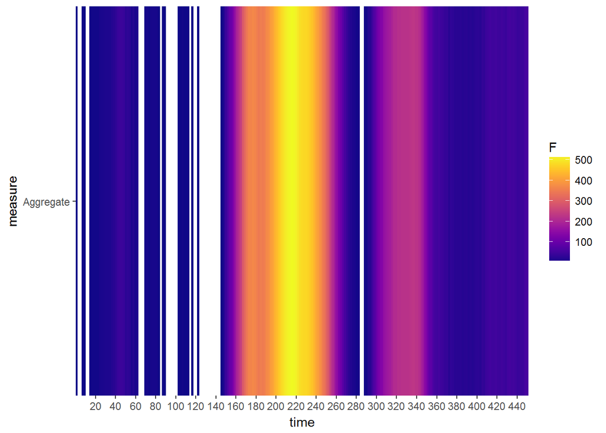

```r
class(perms2) <- c('permutes','data.frame')
plot(perms2,breaks=20*0:(450/20)) #x-axis labeling
```

Having determined a window and an ROI, we can now proceed to the actual modeling step.

## Modeling EEG data using generalized additive mixed modeling

As stated in the beginning, generalized additive mixed models are capable of dealing with the temporal correlation and the spatial correlation that are both still present in our data. We need to slightly modify our data to incorporate the necessary information, which we will achieve using a `dplyr` pipeline; we will also need `tidyr` for its `gather` command. *Install these packages if you do not have them yet.* The pipeline works as follows. First, we subset our data corresponding to our chosen temporal window. Next, we center our timepoint predictor, a step which is not strictly necessary due to implementation details in `mgcv`, but which is recommended standard practice when working with continuous predictors in general. We then reshape our dataset from wide into long format: the columns from `Fp1` to `Cz` will become rows of observations, as is necessary for the spatial smooth which we will use later. The `mutate` command that follows creates two new columns representing the latitude and longitude of our EEG electrodes on the subject’s head (the polar coordinates were obtained directly from Biosemi). Finally, we extract our chosen ROI and drop missing observations.

```r
library(dplyr)
library(tidyr)
part <- MMN %>%
    filter(time > 151, time < 269) %>%
    mutate(time = time - mean(time)) %>%
    gather('electrode','amplitude',Fp1:Cz) %>%
    mutate(lat = recode(electrode,Fp1=6,AF3=5,F7=6,F3=3,FC1=1,FC5=4,T7=6,C3=2,CP1=1,CP5=4,
        P7=6,P3=3,Pz=9,PO3=5,O1=6,Oz=13,O2=13,PO4=12,P4=10,P8=13,CP6=11,CP2=8,C4=9,T8=13,
        FC6=11,FC2=8,F4=10,F8=13,AF4=12,Fp2=13,Fz=9,Cz=7), lon = recode(electrode,Fp1=6,
        AF3=5,F7=2,F3=4,FC1=3,FC5=1,T7=8,C3=8,CP1=11,CP5=9,P7=10,P3=12,Pz=7,PO3=13,O1=14,
        Oz=7,O2=6,PO4=5,P4=4,P8=2,CP6=1,CP2=3,C4=8,T8=8,FC6=9,FC2=11,F4=12,F8=10,AF4=13,
        Fp2=14,Fz=15,Cz=8)) %>%
    filter(electrode %in% .(Fp1,AF3,F7,F3,FC1,FC5,C3,CP1,CP5,CP6,CP2,C4,FC6,FC2,F4,F8,AF4,
        Fp2,Fz),complete.cases(.))
```

Generalized additive mixed models work by assuming that a user-specified set of predictors can be modeled by a user-specified smooth type. As a simple (and rather pointless) example, consider a one-dimensional linear smooth of a hypothetical independent variable $x$ whose values $x_{1\dots 10}$ are the numbers one to ten and whose true effect on the response is to increase it by $\mathcal{N}(3x,1)$. The generalized additive mixed model would fit this effect in two places. First of all, it will perform a smooth-specific transformation to the data points $x_{1\dots 10}$ and store the result as a predictor in $X$. In our example, the smooth is linear (and is hence not really a smooth at all), so this will just result in a column containing the numbers one to ten. This models the fixed part of the smooth; in our example, this effect will be fitted as $\hat{\beta} = 3$. It will also add the same column to $Z$, modeling the wiggly part of the smooth; for our example, its variance should be estimated as $1$.

Of course, a linear smooth is exactly the same as the ordinary combination of a fixed effect and random slope over a dummy grouping factor, by definition. In our analysis of Jager’s (in prep.) EEG data, we will use three different smooths that are much more useful. The first smooth type is known in `mgcv` as `re` (for ‘random effect’). This smooth is a little different from the general case described in the previous paragraph, because it only operates on $Z$, and does not actually add its parameters to $X$ at all. It is discussed first because this is also the only type of smooth (to the author’s knowledge) that, like our linear-smooth example, does not impose a non-linear link function onto the data. These two properties mean that this smooth is exactly equivalent to a simple random effect. This smooth is used four times in our analysis: once to denote a random intercept by participants (in which case the effect’s block in $Z$ will consist of a column of ones for each participant), and three times to denote a random slope by participants (in which case it will be represented by an actual part of the `MMN` dataset).

The second smooth is a thin plate regression spline, which will smooth over the ‘time’ predictor. The number of knots is arbitrarily but reasonably (given the already closely-specified temporal interval) chosen as 5. Note that in the case of the thin plate regression spline these ‘knots’ are actually basis functions; for practical purposes, this distinction is not currently critical. Given the order-2 spline on the sphere and the order-1 thin plate regression spline, we will instruct the model to calculate the *tensor product* of these two splines: this is conceptually (but not mathemathically) similar to an interaction. Mathematically, interactions between two smooths are impossible, hence the name ‘generalized *additive* model’, but the tensor product combines the two smooths together into a single large smooth matrix. Because we use `te()` rather than `ti()`, this matrix contains both the ‘main effects’ of the two splines, as well as their combination (i.e. how the spatial distribution of the EEG activity changes over time).

In addition to this tensor product of two smooths, we include the same tensor product combined with a random effect by participants (modeling how the smooths differ across individuals). Our use of `t2` and `full=TRUE` make this tensor product coincide with what for simplex random smooths is called a ‘factor smooth’, and we pass `m=1` to penalize the first-order derivatives of the smooths (when `m` is a single number, it is applied to all smooths inside a tensor product). This is a stricter penalty than, for instance, enforcing smoothness of the second-order derivatives, which would allow the smooth itself to vary freely in slope, as long as the *changes* in the slopes are relatively small; for non-random smooth terms, this would be sensible to obtain effective smoothing, but for a random smooth it is better to enforce a stronger penalty. This causes the estimated slopes to shrink towards zero, which penalizes overfitting in a similar way to how linear mixed-effects regression penalizes larger values of $u$. For the spline on the sphere and the thin plate regression spline, we pass the same number of knots as we did before (which, we will see below, is gravely suboptimal in terms of computational efficiency), and for the random effect we pass a nonsensical number of 5 (the default value for `k` for 1-dimensional smooths), which is ignored anyway because a random effect *has* no knots.

It is important to keep in mind that *none of these smooth terms are of actual interest*. They *only* serve to compensate for the random differences between participants and for the autocorrelated space and time that are inherent to EEG data. The real predictors of interest are the parametric terms `dev`, `session`, and their interaction. To ease interpretability, we run a separate analysis for both of the two conditions included in the supplied dataset. We then expect significant MMN effects in only some of the conditions and not in others, for theoretical reasons beyond the scope of this vignette. The code used to fit the models is presented below

```r
part$both <- part$dev * part$session #construct interaction term
clusterExport(cl,'part')
pairs <- list(c('S13','S94'),c('S16','S95'))
fun <- function (C) {
    library(mgcv)
    data <- part[part$cond %in% C,]

    form <- amplitude ~ dev*session + s(ppn,bs='re') + s(ppn,by=dev,bs='re') +
        s(ppn,by=session,bs='re') + s(ppn,by=both,bs='re') +
        te(lat,lon,time,bs=c('ds','tp'),d=c(2,1),k=c(19,5)) +
        t2(lat,lon,time,ppn,bs=c('sos','tp','re'),d=c(2,1,1),k=c(19,5,5),m=1,full=TRUE)
    model <- bam(form,data=data,nthreads=8)

    # Figure out the autocorrelation in the residuals. We cannot use acf(resid(m)),
    # because that will not take into account event boundaries (the whole dataset will be
    # treated as a single huge EEG signal)
    AR.start <- data$time == min(data$time)
    res <- resid(model)
    bins <- findInterval(1:length(res),which(AR.start))
    res.binned <- split(res,bins)
    rhos <- sapply(res.binned,function (x) acf(x,plot=FALSE)$acf[2])

    bam(form,data=data,nthreads=8,AR.start=AR.start,rho=mean(rhos))
}
models <- parLapply(cl,pairs,fun)
```

A few bits of this code require some explanation. First, we make a list of data combinations that are of interest to us; it is by this list that we subset the data into our two comparisons. This is not the most straightforward way to segment the data into our two bins of interest, but this is how Jager (in prep.) formatted her data. Then, for each of our two comparisons (which will be run in parallel), we subset our data and then formulate and fit our model, affording it 8 CPU threads. On the computer cluster administrated by the Radboud University Nijmegen, this takes about 5 GiB of RAM per model and about three hours of wall time.

It is very important to mention that by default, `bam` uses (a fast approximation of) the REML criterion (i.e. restricted maximum likelihood), rather than the conventional maximum likelihood, to estimate the smooth parameters. *This means that it is illegitimate to perform model comparisons between models differing in $X$*. Without going into too much detail, the REML criterion can be defined as:

$$\ell_\mathit{REML}(\theta,\sigma | Y) = \int\limits_{-\infty}^\infty \ell(\beta,\theta,\sigma) d\beta$$

where $\ell$ is the likelihood of the data given the current parameter estimates for the model (but in practice, $\ell$ is always replaced by the deviance). The innovation over the traditional likelihood is that the $\beta$ parameter is integrated out just like $u$ was earlier (see the final paragraph of the introduction). This compensates for bias inherent to regular maximum likelihood estimation, which is the same problem we saw in the first paragraph when we formed $\hat{\sigma}$ by dividing the $r^2$ by $n-p$ rather than by $n$. Maximum likelihood finds the values for $\theta$ that maximize the likelihood of the data given $\beta$, $\theta$ and $\sigma$, but it fails to take into account that we have *estimated* $\beta$ by $\hat{\beta}$, which will have introduced error (that again accumulates when squared and takes away variance from the residual error $\sigma$). This is something that should again be compensated just like it is when calculating $\hat{\sigma}$ (or rather $s$) as an unbiased estimator of $\sigma$. This is done by maximizing not the likelihood, but the *restricted* likelihood. As shown above, this REML criterion is calculated by integrating out the fixed effects. In other words, the model maximizes the likelihood of observing the data *for all values of $\beta$*, rather than only the estimated $\hat{\beta}$. Crucially, this means that if two models do not have the same structure for $X$, and hence have different $\beta$s, integrating with respect to $\beta$ amounts to adding a different constant to the likelihood function. *It is then no longer valid to perform model comparisons by comparing the change in deviance to a $\chi^2$ distribution*, since the change in deviance between the two models will also include the change in this integrated constant. If we wanted to do model comparisons (we see no reason to, although a scrutinous linguist might consider the `dev:session` term for exclusion), we would have to refit the models with `method='ML'`.

There is one part of this code that still needs explanation. We actually fit the model not once, but twice. This is because EEG data is often temporally autocorrelated in the residuals, even after including a temporal smooth (De Cat, Klepousniotou, & Baayen, 2015). The first time we fit the model, we only use the resulting fit to determine how large this autocorrelation is. We extract the lag-1 autocorrelation present in the model’s residuals, and then fit the model again, this time informing `bam` that it should take an autocorrelation of that size into account. Note that the true autocorrelation is likely to be much more complex than an AR(1) process, and might be better modeled using an ARMA process instead; however, currently `bam` is only able to fit lag-1 autocorrelated models. It is possible to fit more complex correlation structures using `gamm`, but this routine is much slower, less numerically stable, and, at least when run on these data, often produces singular fits during the optimization process, which is a fatal error in `nlme`. (This is because Pinheiro & Bates (2000) parameterize $\Lambda_\theta$ not in terms of relative covariance, but rather in terms of its reciprocal, viz. relative precision. A singular fit then corresponds to infinite parameter values, from which numerical calculation cannot continue.)

The results of the two (corrected) fits – which are not distributed along with the package due to the large size of the `models` object (the `.RData` file is 2GiB in size) – are shown below:

```r
for (i in 1:2) {
    cat('\n---',pairs[[i]],'---\n')
    print(summary(models[[i]]))
}
```

[output not shown]

[output cut: 15 more lines]

```
## Signif. codes:  0 ‘***’ 0.001 ‘**’ 0.01 ‘*’ 0.05 ‘.’ 0.1 ‘ ’ 1
##
## Approximate significance of smooth terms:
##                          edf  Ref.df        F  p-value
## s(ppn)                 15.47   26.00    3.569  < 2e-16 ***
## s(ppn):dev             25.78   26.00 5721.790  < 2e-16 ***
## s(ppn):session         19.02   20.00 4496.386 1.81e-12 ***
## s(ppn):both            19.30   20.00 8343.386 1.15e-14 ***
## te(lat,lon,time)       71.69   77.68   11.707  < 2e-16 ***
## t2(lat,lon,time,ppn) 1515.23 2545.00 1013.609 4.85e-05 ***
## ---
## Signif. codes:  0 ‘***’ 0.001 ‘**’ 0.01 ‘*’ 0.05 ‘.’ 0.1 ‘ ’ 1
##
## R-sq.(adj) =  0.653   Deviance explained = 65.9%
## fREML = -30484  Scale est. = 0.29661   n = 111203
```

This concludes our analysis of Jager’s (in prep.) EEG data. On a final note, the summary statistics reported here should probably be corrected for multiple comparisons, but my supervisor does not seem to think so, so I’ll leave it at that. If the analyst wants to correct for multiple comparisons, the Sidak correction is a good option:

$$\alpha_\mathit{Sidak} = 1 - (1-\alpha)^\frac{1}{n}$$

If we assume $\alpha = .05$ and divide it by the corrected $\alpha_\mathit{Sidak}$, we conclude that our $p$-values should be multiplied by ~1.97. Note that the actual implementation should be something like:

```r
corrected.summary <- function (summary) {
    correct <- function (table) {
        corr <- .05 / (1 - (1-.05)^(1/2))
        table[,4] <- pmin(table[,4]*corr,1)
        table
    }
    summary$p.table <- correct(summary$p.table)
    summary$s.table <- correct(summary$s.table)
    return(summary)
}
```

to clip the $p$-values to the $[0,1]$ range. ($p$-values exceeding 1 are an error in `R`, and will prevent the summary from being printed.)

# References

Bates, D. M., & DebRoy, S. (2004). Linear mixed models and penalized least squares. *Journal of Multivariate Analysis*, *91*(1), 1–17.

Brysbaert, M. (2007). The language-as-fixed-effect-fallacy: Some simple SPSS solutions to a complex problem. *London: Royal Holloway, University of London*.

De Cat, C., Klepousniotou, E., & Baayen, R. H. (2015). Representational deficit or processing effect? An electrophysiological study of noun-noun compound processing by very advanced L2 speakers of English. *Frontiers in Psychology*, *6*.

Jager, L. (in prep.).

Maris, E., & Oostenveld, R. (2007). Nonparametric statistical testing of eeg-and meg-data. *Journal of Neuroscience Methods*, *164*(1), 177–190.

Pinheiro, J., & Bates, D. M. (2000). *Mixed-effects models in S and S-PLUS*. Springer Science & Business Media.

Wood, S. (2006). *Generalized additive models: An introduction with R*. Chapman; Hall/CRC.